# Exploratory Analysis

## Technological Impacts on Mental Health

### Authors

Jimmy Nguyen (jimmydn@uw.edu)

### Date

Spring 2024

### Abstract

My main goal is to explore the effects of technology, such as social media, on mental health amongst the general population around the world. This domain and the questions that it entails are important because poor mental health is still something widely disregarded as a “priority” despite having such a vast impact on the lives of those who are affected and precipitating even greater issues down the road. To address this issue, I will examine how technology might positively and/or negatively impact one’s mental health, as well as look into how it can influence mental health care/treatments.

### Keywords

mental health; technology; social media; anxiety; depression; tech industry

### Introduction

The goal of this project is to explore how different forms of technology can have varying impacts on one’s mental health, as well as how it can also be used to treat underlying mental health issues or influence said treatments. Some of the questions I hope to answer while exploring this domain include:

- How does social media usage negatively impact mental health across different age groups? Do the negatives outweigh any potential positives of social media for mental health?
- Are workers in tech industries/positions more prone to mental health issues compared to other industries? Does this vary country-by-country?
- Have recent technological advancements been helpful in regards to treating mental health? If so, how effective are they?

These questions are motivated by a desire to understand the role of technology in addressing our everyday mental health, especially with its increasing prevalence in society over time. Answering these questions is important because it would give more insight as to how technology might have different impacts on mental health across different demographics, as well as ultimately guiding healthcare providers, researchers, and other individuals to promoting positive mental health and well-being.

### Related Work

My topic is one that has been a focus of many research papers and related work in the recent years, especially due to the ever-increasing usage of technology in everyday life coinciding with a recent societal push towards mental health awareness. Certain forms of technology, such as social media, have developed a reputation for influencing mental health that has been studied in various research projects and papers. Social networking is vital to developing healthy mental states, but “the quantity and quality of social relationships [can] affect mental health, health behavior, physical health, and mortality risk” (Karim, 2020).

Luckily, technology has also been observed as having “opened a new frontier in mental health care…giving the public, health care providers, and researchers new ways to access help, monitor progress, and increasing understanding of mental health” (“Technology and the Future of Mental Health Treatment”). This is significant, as technological treatments can range anywhere from simple (providing access to crisis text/call lines) to advanced (apps that can monitor behavioral statuses and signal for help when detecting changes). In advanced use cases, technology can be used to “[evaluate] nearly all features of psychiatric disorders, including symptoms, cognitive performance, and everyday functioning” (Harvey, 2022).

##### Works Cited

Harvey, Philip D., et al. “Technology and mental health: State of the art for assessment and treatment.” American Journal of Psychiatry, vol. 179, no. 12, 1 Dec. 2022, pp. 897–914, https://doi.org/10.1176/appi.ajp.21121254.

Karim, Fazida, et al. “Social Media Use and Its Connection to Mental Health: A Systematic Review.” Cureus, U.S. National Library of Medicine, 15 June 2020, www.ncbi.nlm.nih.gov/pmc/articles/PMC7364393/.

“Technology and the Future of Mental Health Treatment.” National Institute of Mental Health, U.S. Department of Health and Human Services, www.nimh.nih.gov/health/topics/technology-and-the-future-of-mental-health-treatment. Accessed 15 May 2024.

### The Datasets

[My first dataset](https://www.kaggle.com/datasets/souvikahmed071/social-media-and-mental-health/data) is from a 2023 survey conducted as part of a data science and machine learning project for a statistics course. The survey was conducted by university students in Dhaka, Bangladesh, and collected data regarding participants’ mental health state and experience with social media.

The dataset has 20 features (21 including a timestamp) and 481 observations.

Some ethical questions that need to be considered when working with a dataset like this include:

- Was the survey conducted in a way that avoids bias in order to accurately capture how technology might affect the participants’ everyday life?
- Were there any groups that might have been underrepresented in the survey, and how would this affect the overall interpretation of the data?
- What are some different ways that this data can be utilized after its collection, and how can it be ensured that this data is used responsibly?

One possible limitation with this dataset would be the location in which the survey was conducted. Since it only involved participants in Dhaka, Bangladesh, it only gives insight into the specific mental health/technology intersectionality of that one country as opposed to a broader view. Another possible limitation with the dataset might be underrepresentation; since the survey was conducted by college students for a course, it’s possible that other college-student participants make up a majority of the data, which means other demographics (graduates, industry workers) might be underrepresented.

[A second dataset I have](https://www.kaggle.com/datasets/osmi/mental-health-in-tech-survey?resource=download) is from a survey conducted in 2014 that measures different attitudes towards mental health from employees in the tech industry.

The dataset contains 26 features (27 including a timestamp) and 1259 observations.

Some ethical questions that need to be considered when working with a dataset like this include:

- Are there any potential risks to employees participating in the survey (i.e., potential negative consequences for employees who respond negatively/express negative feelings about mental health)?
- Were there certain groups of employees that may have been under/overrepresented in the dataset (different skill levels/positions)?
- Were any cultural sensitivities taken into account when collecting the data that may have directly influenced any of the responses?

One possible limitation with this dataset may be the accuracy with which the responses accurately portray opinions on mental health in the modern-day tech field, as the data collected was from 2014.

### Implications

By exploring social media’s impact across different age groups, I hope to see whether certain groups are more prone to the influence of social media, which could possibly be communicated to app designers in order to address this increased influence (changing the design of certain features or apps to ensure groups that are more prone to negative social influence have resources available to them).

By considering this alongside researching how workers in the tech industry might be affected by mental health, both technologists and designers can be informed of ways to promote positive mental health in both the field and in the products that are created in the field.

Finally, by looking into how technology might actually be beneficial in certain cases regarding mental health treatment, policymakers can create well-informed decisions about responsible technology usage and produce guidelines for apps and other forms of technology that ensure the prioritization of user well-being.

### Limitations & Challenges

There are a couple of challenges that I would need to address with the initial project idea. For example, one challenge I might face is making sure the datasets used have accurate and reliable data. Each dataset may have some form of over/underrepresentation due to the nuances of the data collection method and where the data was collected, but it is my responsibility to be aware of any potential biases, as well as to ensure that the data used is actually reliable.

Also, another general challenge would be using the chosen datasets to gather meaningful conclusions and answers to the research questions. How technology might impact the mental state of individuals in the general population might not have a simple and/or direct answer given the complicated relationship between the two (and the prevalence of technology in modern society), and I would ultimately need to be able to navigate these complexities in order to draw reasonable and meaningful interpretations from the datasets.

### Summary Information

My analysis of my initial dataset, the survey pertaining to respondents’ mental states and attitudes towards social media revealed a variety of surprising statistics. For example, there was an extensive range in terms of the ages of the respondents; **the lowest age in the dataset was 13**, while **the highest age in the dataset was 91**.

Additionally, the most common group of social media apps used by the respondents was: **Facebook, Instagram, YouTube.** The most common level of social media usage by the respondents was **More than 5 hours** per day.

Notably, within the dataset, certain groups of respondents were more prone to depression or negative mental health states than others. One of the variables in the dataset recorded how often a respondent felt depressed or “down” on a scale of 1 to 5 (5 being very often). Out of all the occupations of respondents in the survey, **University Students** were most likely to be affected by depressive or negative mental states, with a ratio of **0.2671** of University Student respondents selecting 5 as their answer to this variable.

### Table: Tech Industry Mental Health Awareness By Country (2014)

| Country | Number of Responses | % of Employers Providing Mental Health Benefits | % of Employees Believing Employers Treat Mental And Physical Health Equally |
| --- | --- | --- | --- |
| Australia | 21 | 0.190 | 0.333 |
| Austria | 3 | 0.333 | 0.667 |
| Bahamas, The | 1 | 1.000 | 1.000 |
| Belgium | 6 | 0.333 | 0.000 |
| Bosnia and Herzegovina | 1 | 0.000 | 0.000 |
| Brazil | 6 | 0.000 | 0.000 |
| Bulgaria | 4 | 0.000 | 0.000 |
| Canada | 72 | 0.403 | 0.264 |
| China | 1 | 0.000 | 0.000 |
| Colombia | 2 | 0.000 | 0.500 |
| Costa Rica | 1 | 0.000 | 0.000 |
| Croatia | 2 | 0.500 | 0.500 |
| Czech Republic | 1 | 0.000 | 0.000 |
| Denmark | 2 | 0.000 | 1.000 |
| Finland | 3 | 0.000 | 0.000 |
| France | 13 | 0.154 | 0.231 |
| Georgia | 1 | 0.000 | 0.000 |
| Germany | 45 | 0.111 | 0.378 |
| Greece | 2 | 0.000 | 0.000 |
| Hungary | 1 | 0.000 | 0.000 |
| India | 10 | 0.000 | 0.300 |
| Ireland | 27 | 0.111 | 0.148 |
| Israel | 5 | 0.000 | 0.600 |
| Italy | 7 | 0.000 | 0.000 |
| Japan | 1 | 0.000 | 0.000 |
| Latvia | 1 | 0.000 | 0.000 |
| Mexico | 3 | 0.000 | 0.000 |
| Moldova | 1 | 0.000 | 0.000 |
| Netherlands | 27 | 0.148 | 0.519 |
| New Zealand | 8 | 0.125 | 0.125 |
| Nigeria | 1 | 0.000 | 0.000 |
| Norway | 1 | 1.000 | 0.000 |
| Philippines | 1 | 0.000 | 0.000 |
| Poland | 7 | 0.000 | 0.571 |
| Portugal | 2 | 0.000 | 0.000 |
| Romania | 1 | 0.000 | 0.000 |
| Russia | 3 | 0.333 | 0.000 |
| Singapore | 4 | 0.000 | 0.000 |
| Slovenia | 1 | 0.000 | 0.000 |
| South Africa | 6 | 0.000 | 0.167 |
| Spain | 1 | 0.000 | 0.000 |
| Sweden | 7 | 0.286 | 0.286 |
| Switzerland | 7 | 0.286 | 0.429 |
| Thailand | 1 | 0.000 | 1.000 |
| United Kingdom | 185 | 0.108 | 0.286 |
| United States | 751 | 0.530 | 0.268 |
| Uruguay | 1 | 0.000 | 0.000 |
| Zimbabwe | 1 | 0.000 | 0.000 |

This table showcases survey responses grouped by country, and provides two ratios: the percentage of employees from each country that are aware of their employers providing mental health benefits, and the percentage of employees from each country that believe their employers treat mental and physical health equally in the workplace.

Some notable observations can be made from the table: the United States had the greatest number of employee responses, but only roughly half of the responses were aware that their employer’s faciliated mental health benefits/programs. Additionally, only around 26% of these employees believed their employers actually treat mental and physical health equally.

This can be compared to some place like the Netherlands, where only around 15% of employee responses knew about their employer’s mental health programs, yet over half of the responses believed their employers treated mental and physical health the same.

### Chart 1: Company Mental Health Benefits Per Company Size

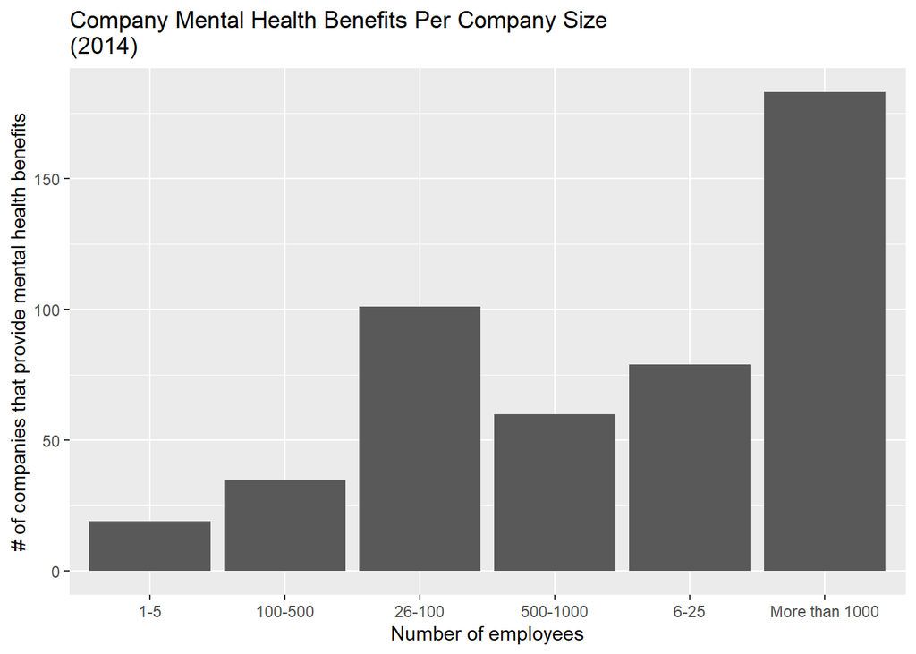

This chart expresses the number of companies that provide mental health benefits, such as therapy or other resources for relieving mental health, across different company sizes. The x-axis shows different company sizes that were options in the survey given to the respondents, while the y-axis expresses the number of companies that do provide mental health benefits per company size, according to the respondents’ answers. I wanted to use this graph to see if there were any trends in regards to mental health accessibility being tied to the size of a company. Surely enough, there were significantly less respondent’s from small companies (1-5) that responded “Yes” to their employers providing mental health benefits compared to larger companies (more than 1000 employees).

### Chart 2: Age and Social Media Comparisons

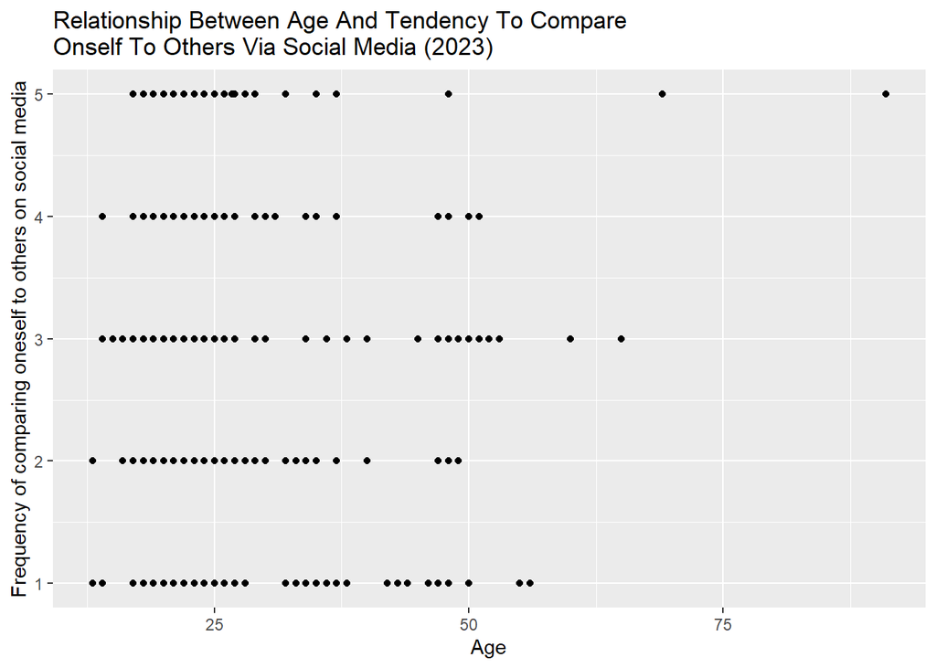

This scatterplot seeks to display the relationship between a respondent’s age and the frequency in which they compare themselves to others via social media (1 being not often, 5 being very often). I wanted to utilize this plot to see if certain ages were less prone to social media comparisons and using social media for “validation”. Surprisingly, there was a relatively even spread of responses across all ages; those around 25 were had answers ranging from 1 to 5, while those around and above 50 mostly answered either 1 or 3, with a few exceptions.

### Chart 3: % Of Social Media Usage Up To 2 Hours By Occupation

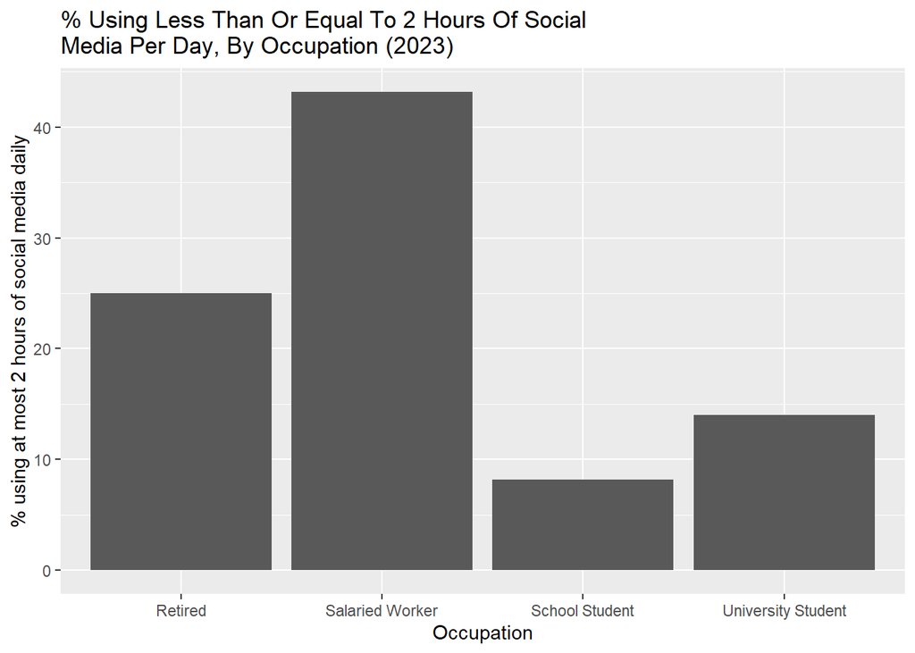

This chart showcases the percentage of respondents who utilize social media for at most 2 hours per day (30 minutes to 2 hours per day is recommended by experts). Salaried workers utilize social media within this time limit the most, with almost 43% of all salary worker respondents answered with “below 30 minutes” or “between 1 and 2 hours”. However, less than 10% of school students keep within this healthy timeframe per day, which means the overwhelming majority of school students utitlize social media for at least 2 hours. I wanted to utilize this chart to visualize trends in how certain occupations may be more prone to social media usage, which can be seen in the varying amounts of respondents using social media for a healthy timeframe per occupation group.